# Encontro dos Saberes RESEX do Rio Ouro Preto (2022)

Análise mamíferos terrestres – 2017 a 2021

Elildo Carvalho Jr - ICMBio/CENAP

2022-04-19

## Apresentação

Este relatório apresenta resultados do Programa Monitora, Subprograma Terrestre, Componente Florestal Global, Alvo Mamíferos terrestres de médio e grande porte, protocolo básico, na **Reserva Extrativista do Rio Ouro Preto**, 2017 a 2021. O principal objetivo é subsidiar o Encontro dos Saberes que será realizado nesta unidade.

## Métodos

O protocolo básico para mamíferos utiliza o método de transecções lineares. Resumidamente, dois observadores percorrem as transecções a uma velocidade constante e registram, para cada avistamento de animais dos grupos-alvo, a espécie, o número de indivíduos e a distância perperndicular entre o primeiro indivíduo avistado e o centro da trilha. Cada UC deve ter pelo menos três transectos de 5 km e o esforço anual mínimo, combinando todos os transectos, deve ser de 150 km percorridos. A tabela 1 apresenta o esforço anual por trilha na Resex do Rio Ouro Preto.

Tabela 1. Esforço de amostragem anual (em km) nas trilhas do ProgramaMonitora na Resex do Rio Ouro Preto, 2017-2021

| EA | nome EA | 2017 | 2018 | 2019 | 2020 | 2021 |
| --- | --- | --- | --- | --- | --- | --- |
| 1 | Francisco Leonel | 54.75 | 51.1 | 51.1 | 43.8 | 47.45 |
| 2 | Manoel Teofilo | 52.00 | 52.0 | 60.0 | 48.0 | 52.00 |
| 3 | Serra Grande | NA | 35.0 | 50.0 | 50.0 | 50.00 |

## Número total de encontros

A tabela 2 apresenta o número total de encontros e de indivíduos avistados por espécie. As espécies mais encontradas foram, nessa ordem: macaco-prego, cutia, mico-de-cheiro, macaco-aranha e zogue-zogue. As outras espécies foram encontradas poucas vezes. Para as espécies que vivem em grupos, o número indivíduos pode ser maior do que o número de encontros.

É importante lembrar que só porque uma espécie foi registrada poucas vezes, não quer dizer necessariamente que ela seja rara. Por exemplo, o protocolo não funciona bem para espécies noturnas como as antas e as pacas, pois as trilhas são percorridas durante o dia, quando essas espécies estão menos ativas. Além disso, espécies que são caçadas podem ficar muito ariscas, fugindo ao menor sinal da aproximação de pessoas.

Tabela 2. Numero de registros por especie obtidos pelo protocolo básicodo Programa Monitora na Resex do Rio Ouro Preto, 2017-2021

| Ordem | Familia | Especie | Nome popular | Encontros | Individuos |
| --- | --- | --- | --- | --- | --- |
| Artiodactyla | Cervidae | Mazama americana | Veado-mateiro | 6 | 6 |
| Artiodactyla | Cervidae | Mazama nemorivaga | Veado-fuboca | 9 | 11 |
| Artiodactyla | Tayassuidae | Pecari tajacu | Caititu | 17 | 45 |
| Artiodactyla | Tayassuidae | Tayassu pecari | Queixada | 5 | 71 |
| Carnivora | Canidae | Cerdocyon thous | Raposinha | 2 | 2 |
| Carnivora | Procyonidae | Nasua nasua | Quati | 4 | 9 |
| Cingulata | Dasypodidae | Dasypus kappleri | Tatu-quinze-quilos | 1 | 1 |
| Cingulata | Dasypodidae | Dasypus novemcinctus | Tatu-galinha | 1 | 1 |
| Pilosa | Myrmecophagidae | Myrmecophaga tridactyla | Tamanduá=bandeira | 1 | 1 |
| Pilosa | Myrmecophagidae | Tamandua tetradactyla | Mambira | 4 | 4 |
| Primates | Atelidae | Ateles chamek | Macaco-aranha | 26 | 107 |
| Primates | Callitrichidae | Saguinus weddelli | Soim | 12 | 43 |
| Primates | Cebidae | Cebus unicolor | Cairara | 5 | 54 |
| Primates | Cebidae | Saimiri ustus | Mico-de-cheiro | 27 | 255 |
| Primates | Cebidae | Sapajus apella | Macaco-prego | 133 | 702 |
| Primates | Pitheciidae | Callicebus brunneus | Zogue-zogue | 19 | 54 |
| Primates | Pitheciidae | Pithecia irrorata | Macaco-velho | 10 | 22 |
| Rodentia | Caviidae | Cavia fulgida | Preá | 1 | 1 |
| Rodentia | Cuniculidae | Cuniculus paca | Paca | 1 | 1 |
| Rodentia | Dasyproctidae | Dasyprocta fuliginosa | Cutia | 66 | 73 |
| Rodentia | Sciuridae | Urosciurus spadiceus | Quatipuru | 13 | 15 |

Figura 1. Número total de encontros por espécie na Resex do Rio Ouro Preto, 2017-2021. Somente espécies com mais de 5 encontros foram incluídas

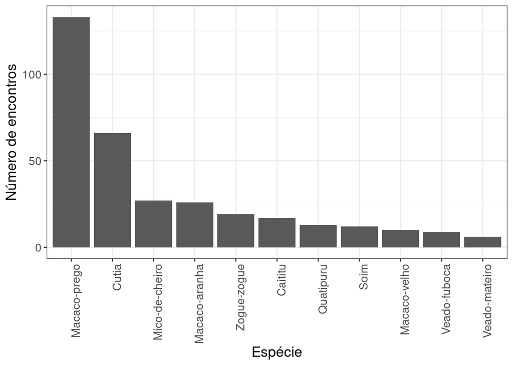

# Tendências populacionais

Somente o macaco-prego e cutia apresentaram taxa de encontro anual média > 0.04 ind/km, o que equivale aproximadamente a um encontro a cada 25 km percorridos (Tabela 3). A Figura 2 mostra que a taxa de avistamento para o macaco-prego diminuiu drasticamente ao longo do monitoramento. Já a taxa de avistamento para a cutia se manteve estável durante a maior parte do tempo, mas sofreu uma queda em 2021 (Figura 3).

As outras especies não tiveram número de encontros suficiente para permitir uma análise de suas tendências populacionais.

Tabela 3. Taxas de encontro anuais na Resex do Rio Ouro Preto

| especie | 2017 | 2018 | 2019 | 2020 | 2021 |
| --- | --- | --- | --- | --- | --- |
| Sapajus apella | 0.31 | 0.23 | 0.22 | 0.13 | 0.09 |
| Dasyprocta fuliginosa | 0.07 | 0.11 | 0.12 | 0.13 | 0.03 |

Figura 2. Taxa de encontro anual para macaco-prego na Resex do Rio Ouro Preto, 2017-2021

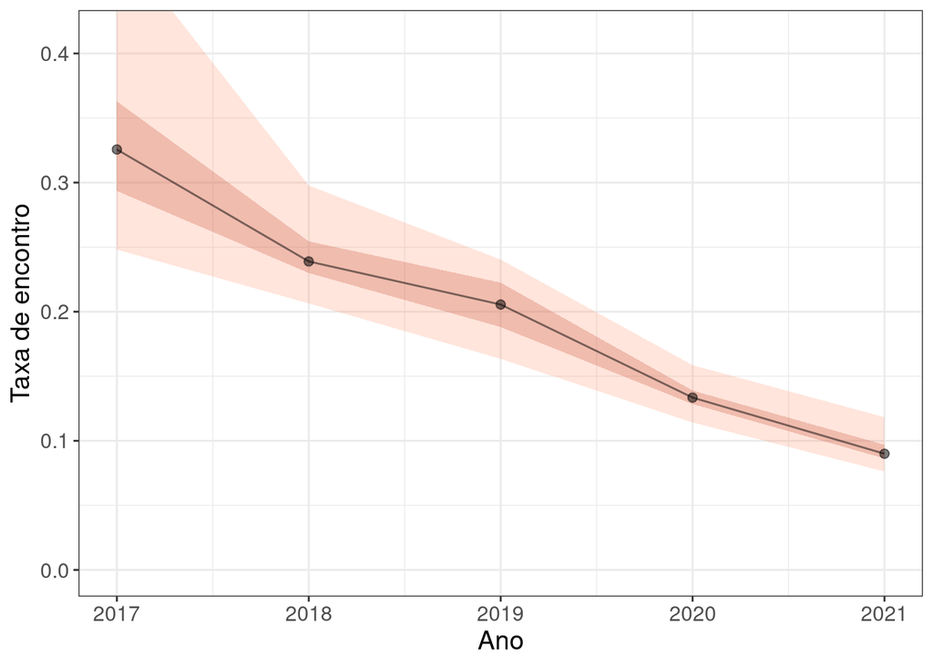

Figura 3. Taxa de encontro anual para cutia na Resex do Rio Ouro Preto, 2017-2021

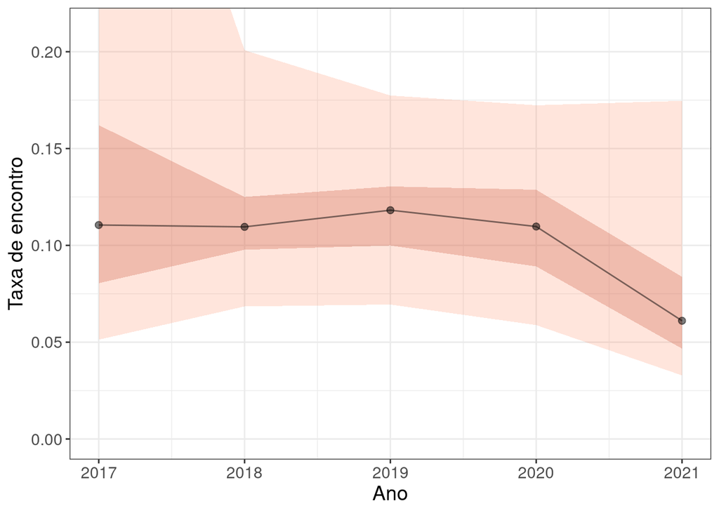

# Tendências populacionais por trilha

A análise anterior avaliou as tendências médias, agregando os dados de todas a trilhas. No entanto, também é importante avaliar o que acontece em cada trilha separadamente. A figura 4 mostra que o macaco-prego declinou em todas as trilhas enquanto que as tendências para a cutia variaram bastante entre as trilhas.

Figura 4. Taxa de encontro anual para macaco-prego por trilha na Resex do Rio Ouro Preto, 2017-2021

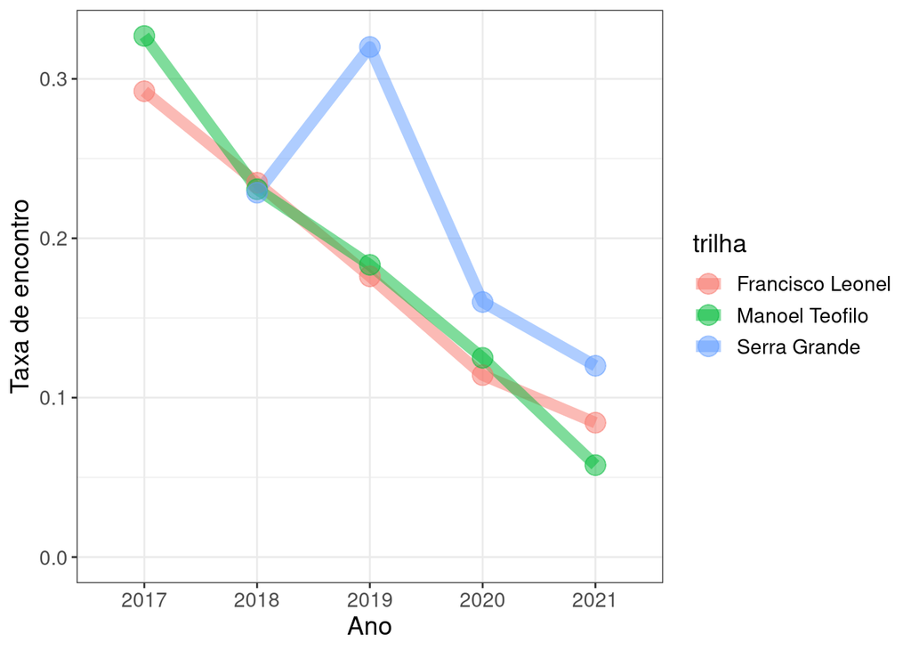

Figura 5. Taxa de encontro anual para cutia por trilha na Resex do Rio Ouro Preto, 2017-2021

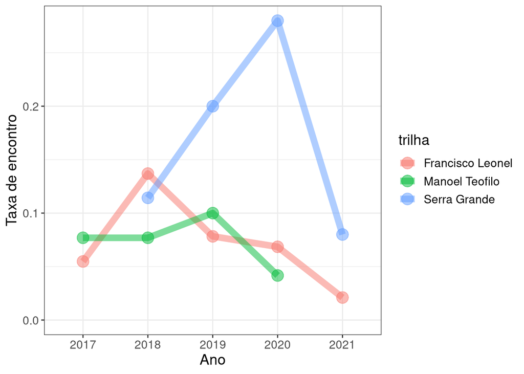

# Perguntas e reflexões

As espécies mais comuns encontradas no monitoramento foram macaco-prego, cutia, mico-de-cheiro, macaco-aranha e zogue-zogue. Isso está de acordo com a percepção da comunidade?

A tendência de queda para o macaco-prego está de acordo com a percepção da comunidade? Como explicar essa tendência? Está acontecendo alguma coisa na região que possa explicar isso?

Como explicar a estabilidade da cutia, e a queda em 2021?

Porque as tendências populacionais para as cutias variaram tanto entre as trilhas?

Porque é importante monitorar várias trilhas ao invés de apenas uma?